# Trabalho do curso de regressão linear - MQ2019

#### 1.2.1.2 Variável independente- Peso 1000lb (wt)

```r
#####wt - Peso (1000 lbs)
summary(dados$wt)
```

```
##    Min. 1st Qu.  Median    Mean 3rd Qu.    Max.
##   1.513   2.581   3.325   3.217   3.610   5.424
```

```r
sd(dados$wt) # Desvio-padrÃ£o
```

```
## [1] 0.9784574
```

```r
var(dados$wt) #variancia
```

```
## [1] 0.957379
```

```r
quantile(dados$wt,0.90, na.rm=T) # Percentil 90
```

```
##    90%
## 4.0475
```

```r
sum(is.na(dados$wt)) # Total de Missings
```

```
## [1] 0
```

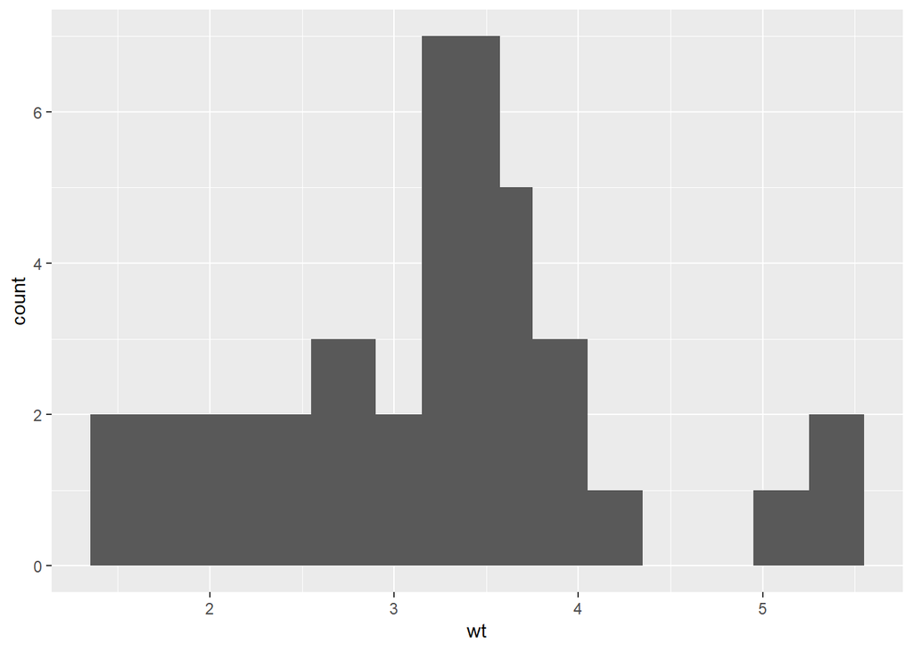

```r
ggplot(dados, aes(x=wt)) + geom_histogram()+ geom_histogram(binwidth=0.3)
```

A distribuição da variável peso sugerem que esta apresenta uma distribuição normal, e tem uma caracteristica simétrica. As estatisticas descritivas reforçam isto já que os valores da mediana e média são bem próximos e os valores parecem bem distribuidos entre os quartis. O desvio padrão apresenta um valor razoavel, e o valor máximo não é muito distante do percitil 90.Não existem valores faltantes nestes dados.

#### 1.2.1.3 Variável independente- Potência bruta (hp)

```r
####hp - Potência bruta (cavalos de força)
summary(dados$hp)
```

```
##    Min. 1st Qu.  Median    Mean 3rd Qu.    Max.
##    52.0    96.5   123.0   146.7   180.0   335.0
```

```r
sd(dados$hp) # Desvio-padrÃ£o
```

```
## [1] 68.56287
```

```r
var(dados$hp) #variancia
```

```
## [1] 4700.867
```

```r
quantile(dados$hp,0.90, na.rm=T) # Percentil 90
```

```
##   90%
## 243.5
```

```r
sum(is.na(dados$hp)) # Total de Missings
```

```
## [1] 0
```

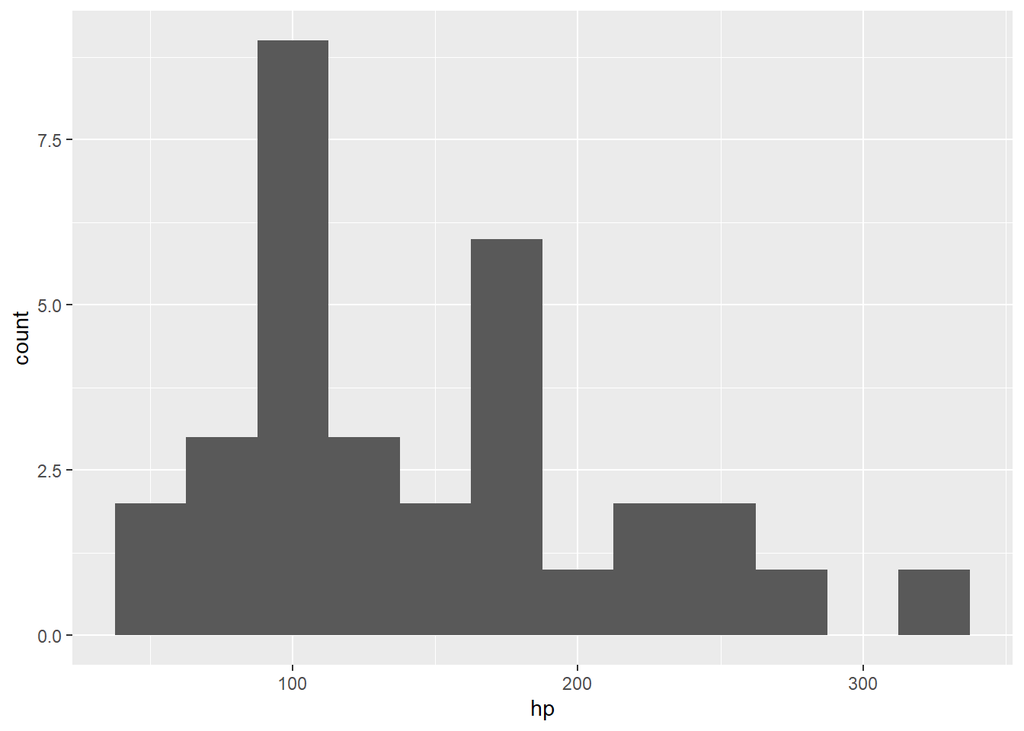

```r
ggplot(dados, aes(x=hp)) + geom_histogram()+geom_histogram(binwidth=25)
```

A variável potência bruta aparenta ter uma distribuição em sino, porém um pouco deslocada para a esquerda. Essa assimetria dos dados é confirmada pelas estaticas ao observar a diferença no valor da mediana e a média, e a distribuição dos quartis.Não existem valores faltantes nestes dados.

#### 1.2.1.4 Variável independente- Deslocamento (disp)

```r
summary(dados$disp)
```

```
##    Min. 1st Qu.  Median    Mean 3rd Qu.    Max.
##    71.1   120.8   196.3   230.7   326.0   472.0
```

```r
sd(dados$disp) # Desvio-padrÃ£o
```

```
## [1] 123.9387
```

```r
var(dados$disp) #variancia
```

```
## [1] 15360.8
```

```r
quantile(dados$disp,0.90, na.rm=T) # Percentil 90
```

```
## 90%
## 396
```

```r
sum(is.na(dados$disp)) # Total de Missings
```

```
## [1] 0
```

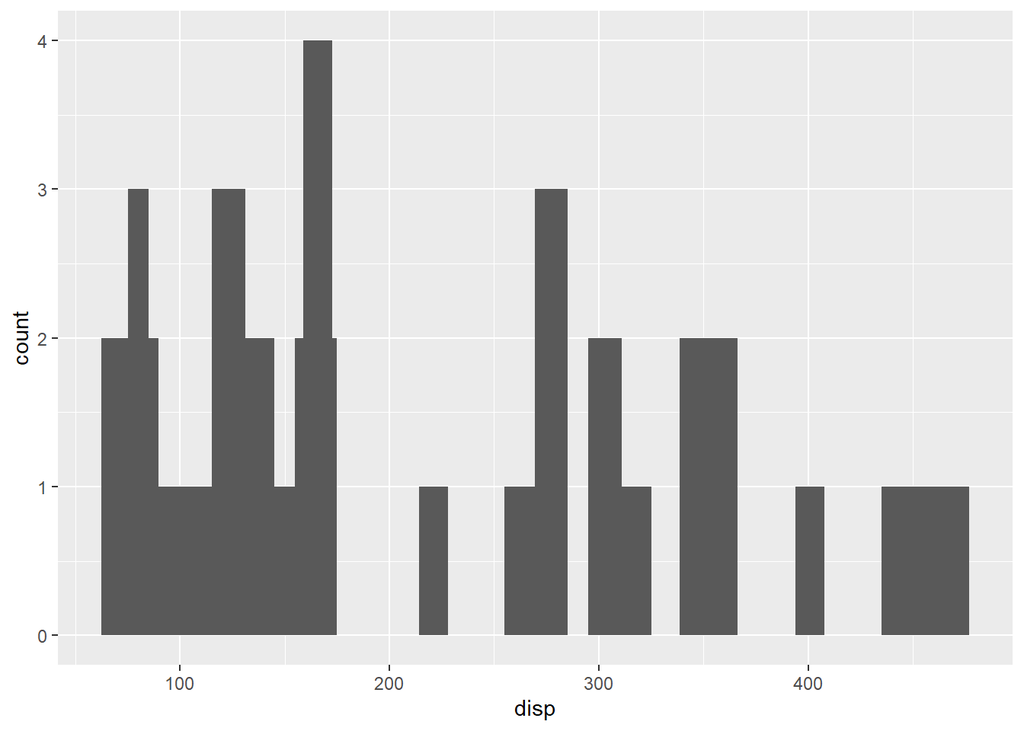

```r
ggplot(dados, aes(x=disp)) + geom_histogram()+geom_histogram(binwidth=10)
```

#### 1.2.1.5 Variável independente- Rácio do eixo traseiro (drat)

```r
#####drat - Rácio do eixo traseiro
summary(dados$drat)
```

```
##    Min. 1st Qu.  Median    Mean 3rd Qu.    Max.
##   2.760   3.080   3.695   3.597   3.920   4.930
```

```r
sd(dados$drat) # Desvio-padrÃ£o
```

```
## [1] 0.5346787
```

```r
var(dados$drat) #variancia
```

```
## [1] 0.2858814
```

```r
quantile(dados$drat,0.90, na.rm=T) # Percentil 90
```

```
##   90%
## 4.209
```

```r
sum(is.na(dados$drat)) # Total de Missings
```

```
## [1] 0
```

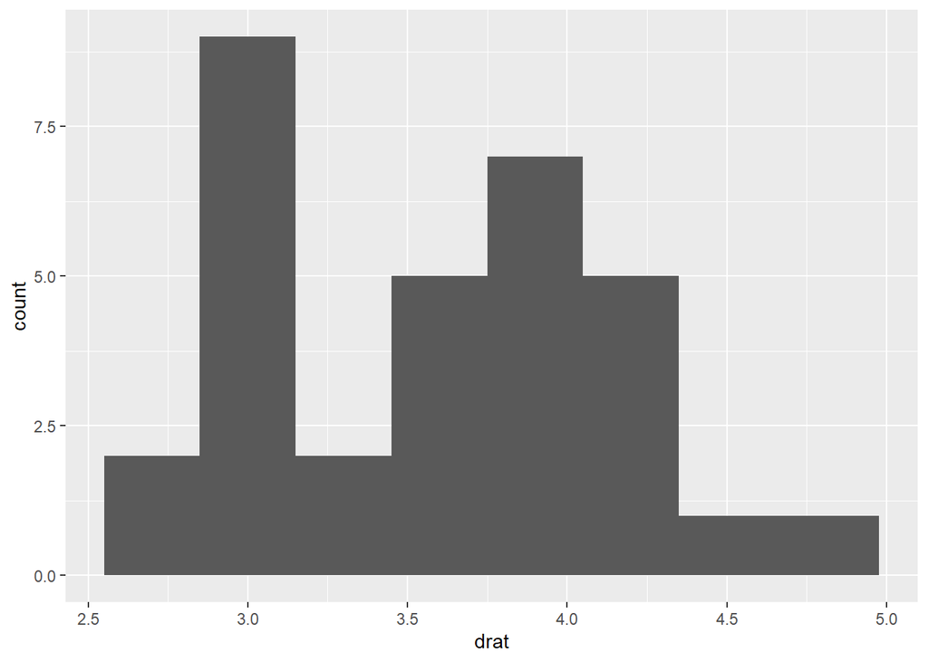

```r
ggplot(dados, aes(x=drat)) + geom_histogram()+ geom_histogram(binwidth=0.3)
```

#### 1.2.1.6 Variável independente- Tempo de 1/4 de milha (qsec)

```r
#####qsec - Tempo de 1/4 de milha#####
sd(dados$qsec) # Desvio-padrÃ£o
```

```
## [1] 1.786943
```

```r
var(dados$qsec) #variancia
```

```
## [1] 3.193166
```

```r
quantile(dados$qsec,0.90, na.rm=T) # Percentil 90
```

```
##   90%
## 19.99
```

```r
sum(is.na(dados$qsec)) # Total de Missings
```

```
## [1] 0
```

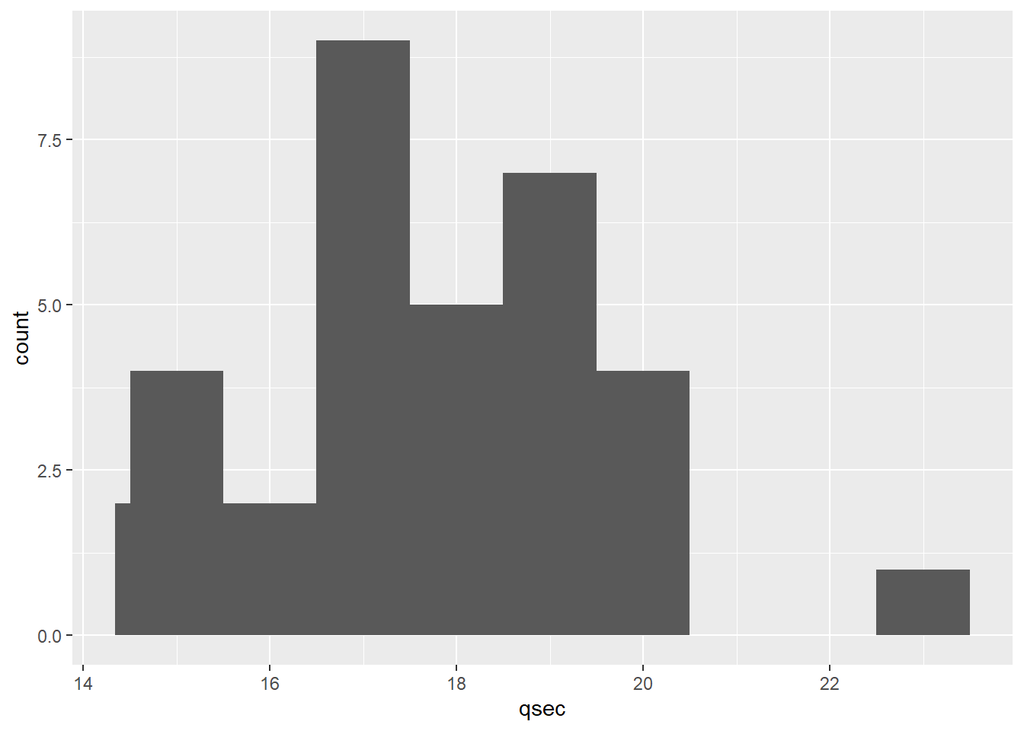

```r
ggplot(dados, aes(x=qsec)) + geom_histogram()+ geom_histogram(binwidth=1)
```

### 1.2.2 Variáveis categóricas

#### 1.2.2.1 Variável categórica- Transmissão (am)

```r
#######am - Transmissão (0 = automatica, 1 = manual)#####
cbind(tabela =table(dados$am),
      proporção =prop.table(table(dados$am)))
```

```
##   tabela proporção
## 0     19   0.59375
## 1     13   0.40625
```

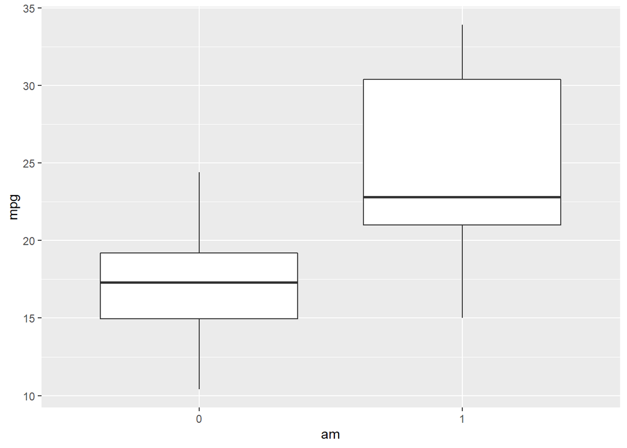

```r
#BOXPLOT x mpg
ggplot(dados, aes(x=am, y=mpg)) +  geom_boxplot()
```

```r
### MÉDIA mpg  por categoria de am
aggregate(mpg~am, dados, mean )
```

| am | mpg |
| --- | --- |
| 0 | 17.14737 |
| 1 | 24.39231 |

A variável transmissão é uma variável binária, que é representada nos dados pelo valor 0 para tranasmissão automática, e 1 para transmissão manual. Aproximadamente 60% dos carros dos dados tem transmissão automática, e 40% tem manual.

#### 1.2.2.2 Variável categórica- Número de cilindros (cyl)

```r
#######cyl - Número de cilindros- Factor w/ 3 levels "4","6","8"#####
cbind(tabela =table(dados$cyl),
      proporcao =prop.table(table(dados$cyl)))
```

```
##   tabela proporcao
## 4     11   0.34375
## 6      7   0.21875
## 8     14   0.43750
```

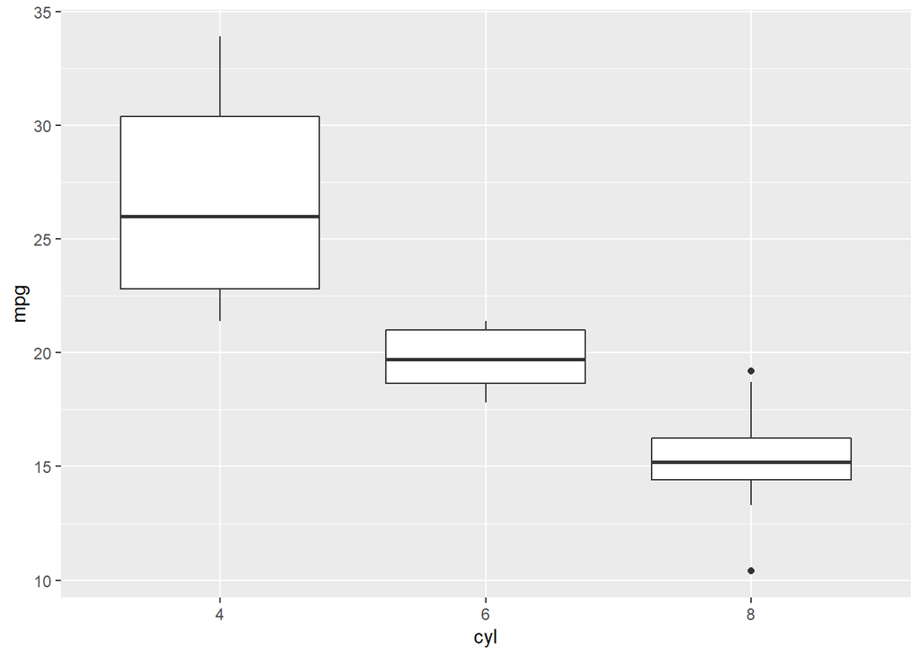

```r
#BOXPLOT x mpg
ggplot(dados, aes(x=cyl, y=mpg)) +  geom_boxplot()
```

```r
### MÉDIA mpg  por categoria de cyl
aggregate(mpg~cyl, dados, mean )
```

| cyl | mpg |
| --- | --- |
| 4 | 26.66364 |
| 6 | 19.74286 |
| 8 | 15.10000 |

#### 1.2.2.3 Variável categórica- V/S (vs)

```r
#######vs - V/S-Factor w/ 2 levels "0","1##################
cbind(tabela =table(dados$vs),
      proporção =prop.table(table(dados$vs)))
```

```
##   tabela proporção
## 0     18    0.5625
## 1     14    0.4375
```

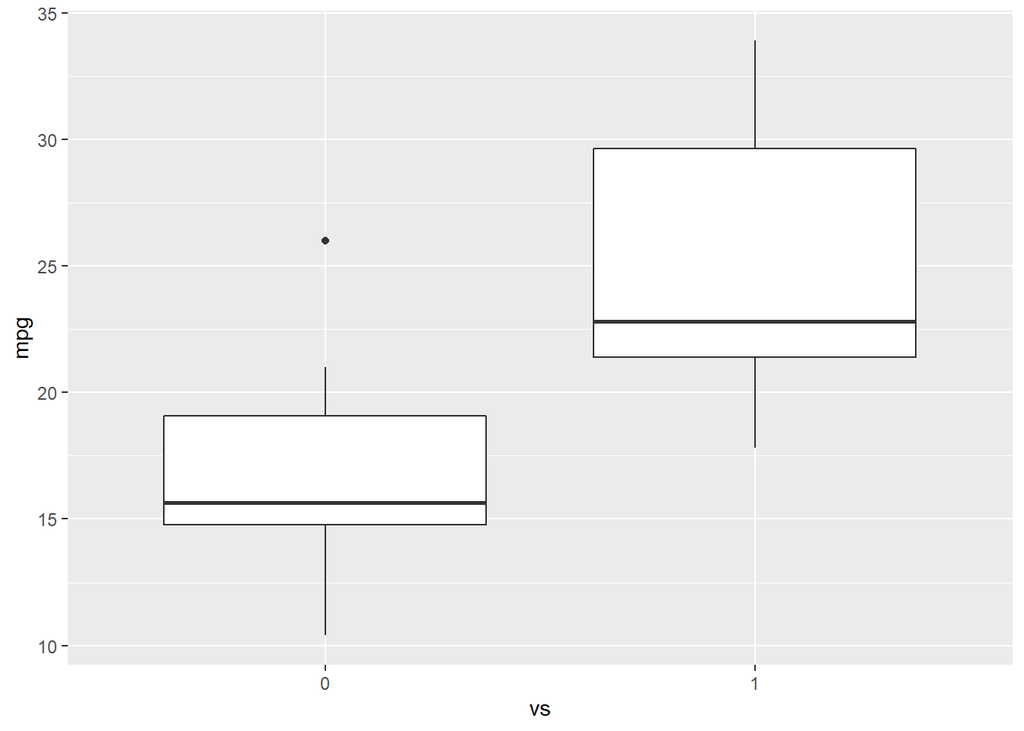

```r
#BOXPLOT x mpg
ggplot(dados, aes(x=vs, y=mpg)) +  geom_boxplot()
```

```r
### MÉDIA mpg  por categoria de vs
aggregate(mpg~vs, dados, mean )
```

| vs | mpg |
| --- | --- |
| 0 | 16.61667 |
| 1 | 24.55714 |

#### 1.2.2.3 Variável categórica- Número de engrenagens (gear)

```r
#######gear - Número de engrenagens-Factor w/ 3 levels "3","4","5"#####
cbind(tabela =table(dados$gear),
      proporção =prop.table(table(dados$gear)))
```

```
##   tabela proporção
## 3     15   0.46875
## 4     12   0.37500
## 5      5   0.15625
```

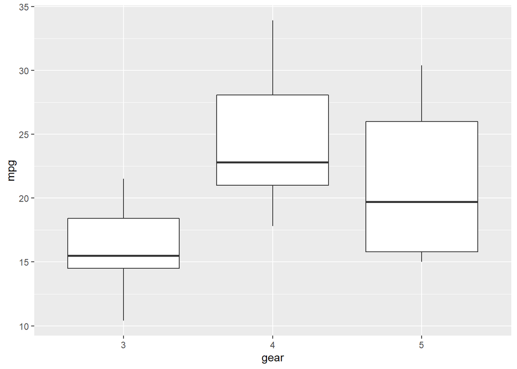

```r
#BOXPLOT x mpg
ggplot(dados, aes(x=gear, y=mpg)) +  geom_boxplot()
```

```r
### MÉDIA mpg  por categoria de gear
aggregate(mpg~gear, dados, mean )
```

| gear | mpg |
| --- | --- |
| 3 | 16.10667 |
| 4 | 24.53333 |
| 5 | 21.38000 |

#### 1.2.2.4 Variável categórica- Número de carburadores (carb)

```r
#######carb - Número de carburadores#####
cbind(tabela =table(dados$carb),
      proporção =prop.table(table(dados$carb)))
```

```
##   tabela proporção
## 1      7   0.21875
## 2     10   0.31250
## 3      3   0.09375
## 4     10   0.31250
## 6      1   0.03125
## 8      1   0.03125
```

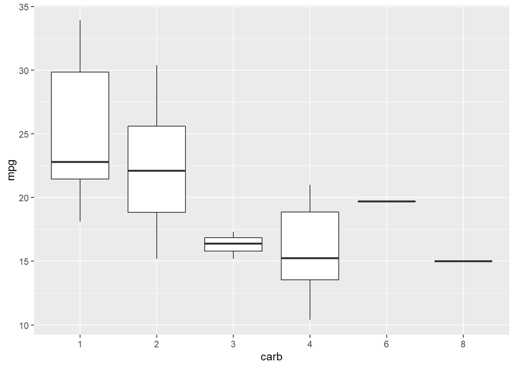

```r
ggplot(dados, aes(x=carb, y=mpg)) +  geom_boxplot()
```

```r
### MÉDIA mpg  por categoria de carb
aggregate(mpg~carb, dados, mean )
```

| carb | mpg |
| --- | --- |
| 1 | 25.34286 |
| 2 | 22.40000 |
| 3 | 16.30000 |
| 4 | 15.79000 |
| 6 | 19.70000 |
| 8 | 15.00000 |

# Questão 3 - Em produção

## 3.1 Análise de correlação

### 3.1.1 mpg x hp

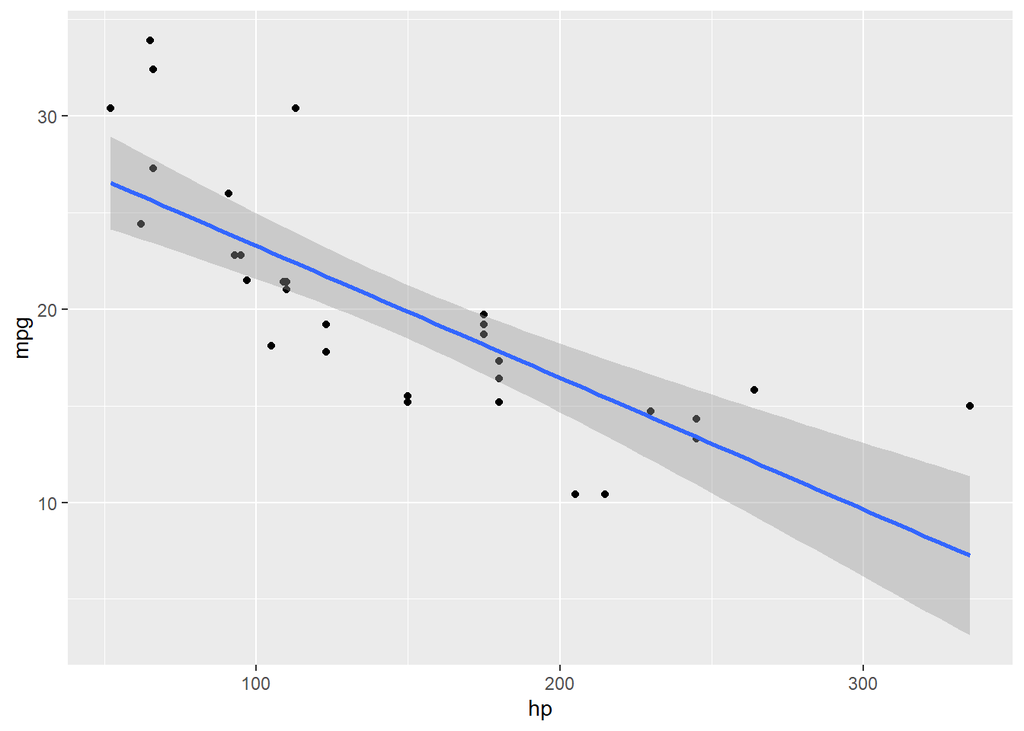

```r
#dispersão hp
ggplot(dados, aes(x=hp, y=mpg)) +
  geom_point()+
  geom_smooth(method=lm)
```

```r
cor(dados$mpg,dados$hp)
```

```
## [1] -0.7761684
```

```r
mod1=lm(dados$mpg~dados$hp)
summary(mod1)
```

```
##
## Call:
## lm(formula = dados$mpg ~ dados$hp)
##
## Residuals:
##     Min      1Q  Median      3Q     Max
## -5.7121 -2.1122 -0.8854  1.5819  8.2360
##
## Coefficients:
##             Estimate Std. Error t value Pr(>|t|)
## (Intercept) 30.09886    1.63392  18.421  < 2e-16 ***
## dados$hp    -0.06823    0.01012  -6.742 1.79e-07 ***
## ---
## Signif. codes:  0 '***' 0.001 '**' 0.01 '*' 0.05 '.' 0.1 ' ' 1
##
## Residual standard error: 3.863 on 30 degrees of freedom
## Multiple R-squared:  0.6024, Adjusted R-squared:  0.5892
## F-statistic: 45.46 on 1 and 30 DF,  p-value: 1.788e-07
```

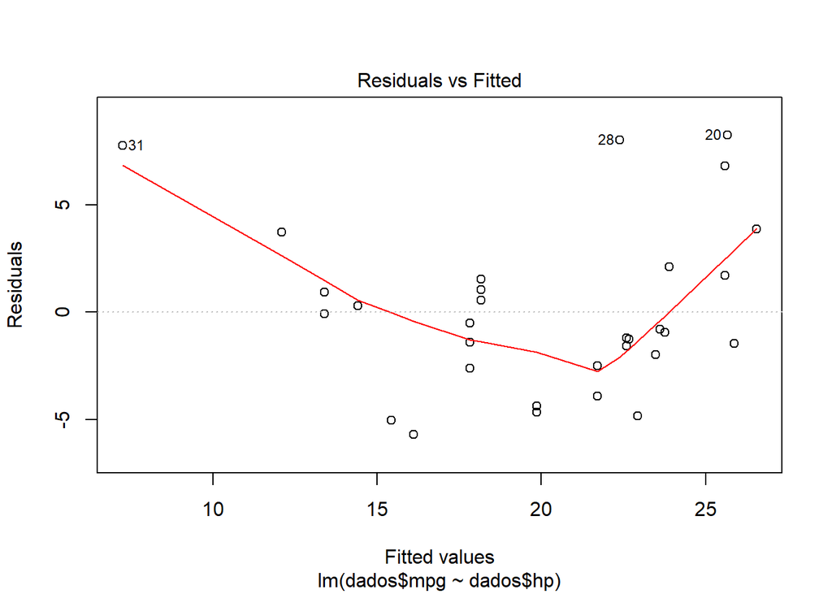

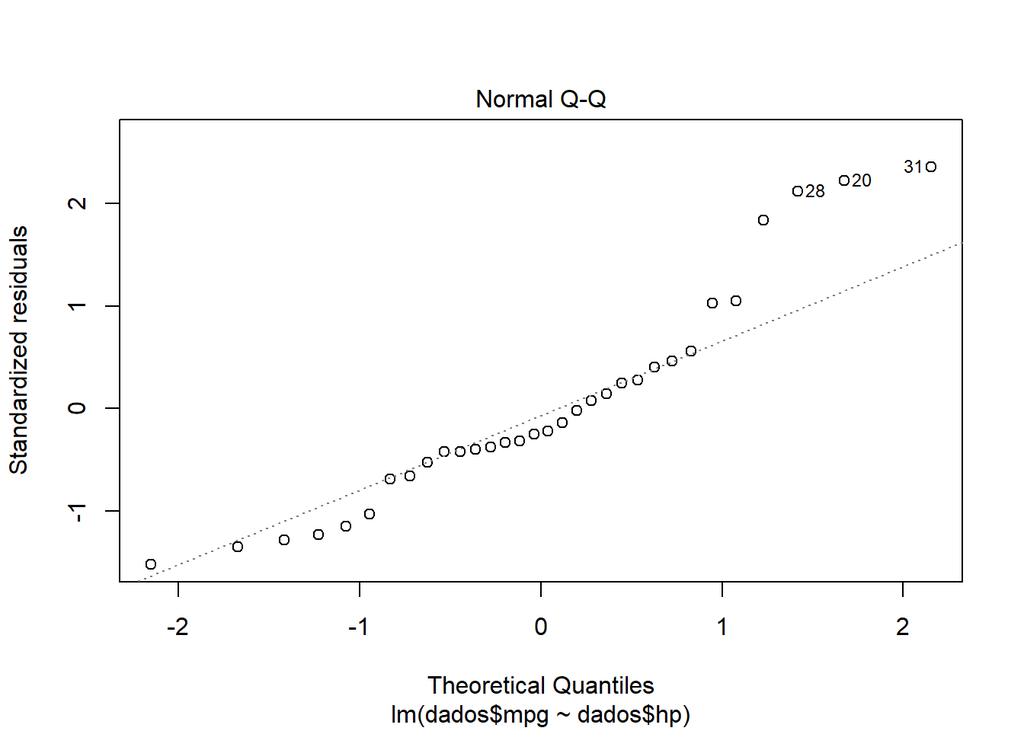

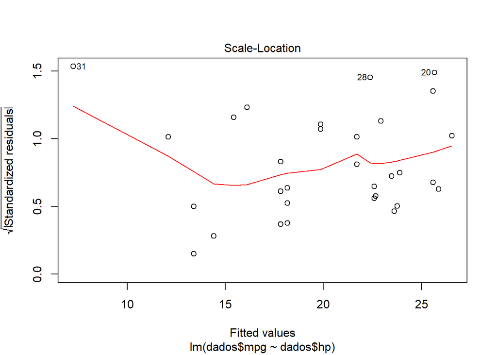

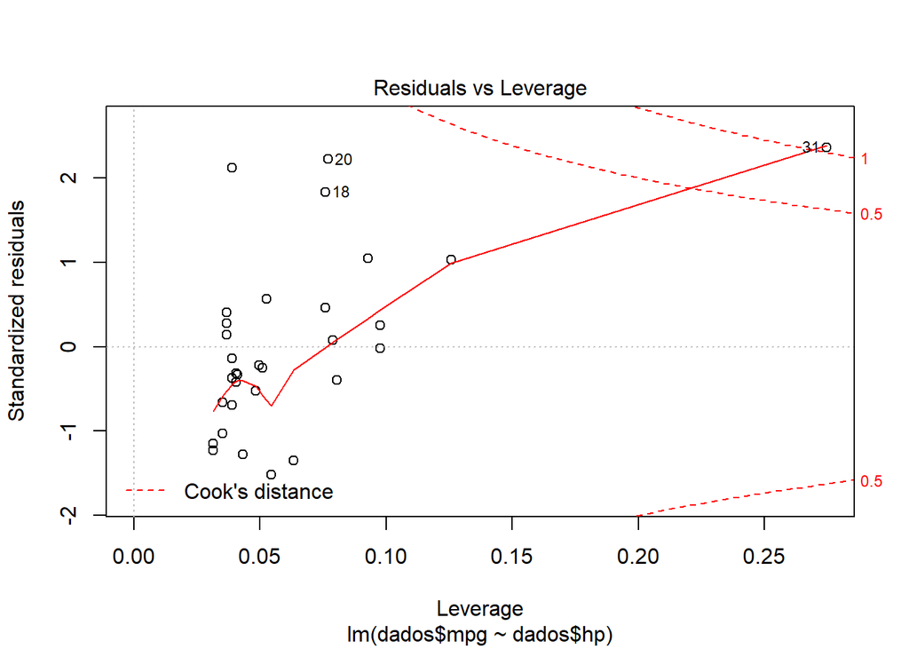

```r
plot(mod1)
```